# Human Deveopment Index and Gender Inequality Index

Swastika Mohapatra MDS202245

10/30/2022

### Introduction

The Human Development Index (HDI) is a statistic that rank countries into four tiers of human development.These four categories are - Very high development, High development, Medium development and low development. Mathematically, it is the geometric mean of life expectancy, gross national income per capita and education. Education is the arithmetic mean of mean years of schooling completed and expected years of schooling upon entering the education system.

The Gender Inequality Index is a statistic used to quantify the loss of achievement within a country due to gender inequality.It has 3 critical dimensions : reproductive health, empowerment, and labor market participation.

### Data Description

For this analysis, 3 datasets were used - 1. Human development index and its components, 2. Trends in human development index 1990-2021, 3. Gender Inequality index.

The first dataset comprises of HDI value for each country along with the 4 components of HDI and the development category that the country falls into.

The second dataset comporises of HDI value for each country for 8 years spanning from 1990 to 2021.

The third dataset comprises of GII value for each country along with all its components and the development catagory that the country falls into based on GII.

The datasets were taken from UNDP’s Human Development Report website.

The datasets had some missing values that were replaced with the median value of their respective columns.

### Stacked barchart

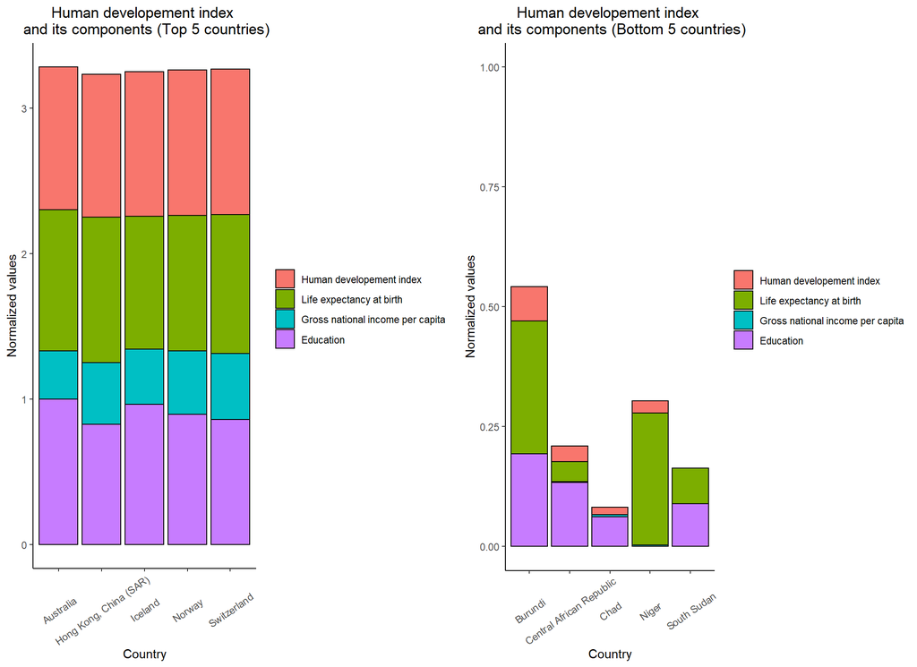